# Multiple Linear Regression

Jordan Sutherland

04/28/2021

## North Carolina Births

This is the same data we used for Lab 4. In 2004, the state of North Carolina released to the public a large data set containing information on births recorded in this state. This data set has been of interest to medical researchers who are studying the relation between habits and practices of expectant mothers and the birth of their children. We will work with a sample of observations from this data set. These cases were chosen at random.

We have observations on 13 different variables, some categorical and some numerical. The meaning of each variable is as follows.

We will try to fit a model where the response variable is the birth weight in pounds `weight`. We are interested in identifying the best predictors among the other available variables. In this case, we will exclude the variable `fage` from the analysis as it contains a large quantity of missing values.

Let’s load the `nc` data set into our workspace, remove the `fage` variable and exclude records with missing values.

```r
nc <- read.csv("nc.csv", header=T)
# remove first column, 'fage' variable
nc <- nc[,-1]
# remove records with missing values
nc <- na.omit(nc)
dim(nc)
```

```
## [1] 962  12
```

```r
attach(nc)
```

## Homework - Due on Monday, April 26 by 2pm

1. Explore the data and identify which predictors you would include in the model. Look for possible issues with collinearity. Are there any variables you would not include? Explain. (hint: notice that the `mature` variable is simply a categorization of the variable `mage`. Hence, we only include `mage` because it contains more information. Check for similar patterns with other variables and exclude them form the analysis. You should end up with 8 predictors in the initial model.)

**Resp:** The variables I would not include are `mature`,`premie`, and `lowbirthweight`. All of these variables are just categorizations of `mage`, `weeks`, and `weight` respectively.

2. Fit a model including all the variables you chose in question 1 (please fit an additive model i.e no interaction terms). What percentage of variation in birth weight is explained by the model? Is this a good model? Explain.

**Resp:** 47.28% of the variation in birth weight can be explained by the model. This is a relatively low R-squared so this is not a good model and can be improved.

```r
fit <- lm(weight ~ mage + weeks + visits + marital + gained + gender + habit + whitemom, data=nc)
summary(fit)
```

```
##
## Call:
## lm(formula = weight ~ mage + weeks + visits + marital + gained +
##     gender + habit + whitemom, data = nc)
##
## Residuals:
##     Min      1Q  Median      3Q     Max
## -3.7880 -0.6514 -0.0180  0.6827  4.1705
##
## Coefficients:
##                     Estimate Std. Error t value Pr(>|t|)
## (Intercept)        -6.371455   0.508634 -12.527  < 2e-16 ***
## mage                0.007149   0.006299   1.135 0.256668
## weeks               0.329306   0.012517  26.309  < 2e-16 ***
## visits             -0.004843   0.009249  -0.524 0.600666
## maritalnot married  0.240029   0.084453   2.842 0.004576 **
## gained              0.009252   0.002465   3.753 0.000185 ***
## gendermale          0.384233   0.069431   5.534 4.04e-08 ***
## habitsmoker        -0.377704   0.105806  -3.570 0.000375 ***
## whitemomwhite       0.206161   0.082111   2.511 0.012212 *
## ---
## Signif. codes:  0 '***' 0.001 '**' 0.01 '*' 0.05 '.' 0.1 ' ' 1
##
## Residual standard error: 1.073 on 953 degrees of freedom
## Multiple R-squared:  0.4728, Adjusted R-squared:  0.4684
## F-statistic: 106.8 on 8 and 953 DF,  p-value: < 2.2e-16
```

3. Are there any predictors that are not significant? Is the saturated model with all the predictors the best model? Use backward elimination to find the best model i.e take not significant variables out one at a time (take the variable with highest t-test p-value out first). Justify the choice of your final model both based on the adjusted R-squared and a formal test. (hint: use `anova` to compare models and make your final decision).

```r
anova(fit)
```

```
## Analysis of Variance Table
##
## Response: weight
##            Df  Sum Sq Mean Sq  F value    Pr(>F)
## mage        1    5.14    5.14   4.4648  0.034861 *
## weeks       1  887.72  887.72 770.8629 < 2.2e-16 ***
## visits      1    0.07    0.07   0.0610  0.805014
## marital     1   19.86   19.86  17.2433 3.583e-05 ***
## gained      1   18.41   18.41  15.9893 6.863e-05 ***
## gender      1   32.54   32.54  28.2570 1.323e-07 ***
## habit       1   13.23   13.23  11.4912  0.000728 ***
## whitemom    1    7.26    7.26   6.3039  0.012212 *
## Residuals 953 1097.47    1.15
## ---
## Signif. codes:  0 '***' 0.001 '**' 0.01 '*' 0.05 '.' 0.1 ' ' 1
```

```r
fit1 <- lm(weight ~ mage + weeks + marital + gained + gender + habit + whitemom, data=nc)
summary(fit1)
```

```
##
## Call:
## lm(formula = weight ~ mage + weeks + marital + gained + gender +
##     habit + whitemom, data = nc)
##
## Residuals:
##     Min      1Q  Median      3Q     Max
## -3.7661 -0.6445 -0.0203  0.6884  4.1785
##
## Coefficients:
##                     Estimate Std. Error t value Pr(>|t|)
## (Intercept)        -6.379330   0.508219 -12.552  < 2e-16 ***
## mage                0.006874   0.006275   1.096 0.273559
## weeks               0.328288   0.012360  26.560  < 2e-16 ***
## maritalnot married  0.233431   0.083476   2.796 0.005271 **
## gained              0.009184   0.002461   3.732 0.000201 ***
## gendermale          0.385671   0.069350   5.561 3.48e-08 ***
## habitsmoker        -0.374960   0.105636  -3.550 0.000405 ***
## whitemomwhite       0.206720   0.082073   2.519 0.011940 *
## ---
## Signif. codes:  0 '***' 0.001 '**' 0.01 '*' 0.05 '.' 0.1 ' ' 1
##
## Residual standard error: 1.073 on 954 degrees of freedom
## Multiple R-squared:  0.4727, Adjusted R-squared:  0.4688
## F-statistic: 122.1 on 7 and 954 DF,  p-value: < 2.2e-16
```

```r
anova(fit1)
```

```
## Analysis of Variance Table
##
## Response: weight
##            Df  Sum Sq Mean Sq  F value    Pr(>F)
## mage        1    5.14    5.14   4.4682 0.0347913 *
## weeks       1  887.72  887.72 771.4498 < 2.2e-16 ***
## marital     1   19.73   19.73  17.1486 3.763e-05 ***
## gained      1   18.19   18.19  15.8052 7.551e-05 ***
## gender      1   32.79   32.79  28.4953 1.174e-07 ***
## habit       1   13.05   13.05  11.3386 0.0007895 ***
## whitemom    1    7.30    7.30   6.3440 0.0119404 *
## Residuals 954 1097.78    1.15
## ---
## Signif. codes:  0 '***' 0.001 '**' 0.01 '*' 0.05 '.' 0.1 ' ' 1
```

```r
fit2 <- lm(weight ~ weeks + marital + gained + gender + habit + whitemom, data=nc)
summary(fit2)
```

```
##
## Call:
## lm(formula = weight ~ weeks + marital + gained + gender + habit +
##     whitemom, data = nc)
##
## Residuals:
##     Min      1Q  Median      3Q     Max
## -3.7541 -0.6627 -0.0232  0.6865  4.2226
##
## Coefficients:
##                     Estimate Std. Error t value Pr(>|t|)
## (Intercept)        -6.175189   0.472875 -13.059  < 2e-16 ***
## weeks               0.327327   0.012330  26.547  < 2e-16 ***
## maritalnot married  0.270632   0.076265   3.549 0.000406 ***
## gained              0.008987   0.002455   3.661 0.000265 ***
## gendermale          0.385131   0.069355   5.553 3.64e-08 ***
## habitsmoker        -0.382962   0.105394  -3.634 0.000294 ***
## whitemomwhite       0.210240   0.082019   2.563 0.010520 *
## ---
## Signif. codes:  0 '***' 0.001 '**' 0.01 '*' 0.05 '.' 0.1 ' ' 1
##
## Residual standard error: 1.073 on 955 degrees of freedom
## Multiple R-squared:  0.472,  Adjusted R-squared:  0.4687
## F-statistic: 142.3 on 6 and 955 DF,  p-value: < 2.2e-16
```

```r
anova(fit2)
```

```
## Analysis of Variance Table
##
## Response: weight
##            Df  Sum Sq Mean Sq  F value    Pr(>F)
## weeks       1  880.87  880.87 765.3395 < 2.2e-16 ***
## marital     1   30.40   30.40  26.4154 3.339e-07 ***
## gained      1   17.37   17.37  15.0941 0.0001093 ***
## gender      1   32.60   32.60  28.3215 1.281e-07 ***
## habit       1   13.73   13.73  11.9294 0.0005768 ***
## whitemom    1    7.56    7.56   6.5706 0.0105199 *
## Residuals 955 1099.16    1.15
## ---
## Signif. codes:  0 '***' 0.001 '**' 0.01 '*' 0.05 '.' 0.1 ' ' 1
```

4. Ideally we want the regression sum of squares (SS(Regression) in the class notes) to be large relative to the residuals sum of squares (SS(Residuals)). What are the values for SS(Regression) and SS(Residuals) in your final model? (hint: use `anova`).

**Resp:** The value for SS(Regression) in my final model is 982.53. The value for SS(Residuals) in my final model is 1099.16.

```r
anova(fit2)
```

```
## Analysis of Variance Table
##
## Response: weight
##            Df  Sum Sq Mean Sq  F value    Pr(>F)
## weeks       1  880.87  880.87 765.3395 < 2.2e-16 ***
## marital     1   30.40   30.40  26.4154 3.339e-07 ***
## gained      1   17.37   17.37  15.0941 0.0001093 ***
## gender      1   32.60   32.60  28.3215 1.281e-07 ***
## habit       1   13.73   13.73  11.9294 0.0005768 ***
## whitemom    1    7.56    7.56   6.5706 0.0105199 *
## Residuals 955 1099.16    1.15
## ---
## Signif. codes:  0 '***' 0.001 '**' 0.01 '*' 0.05 '.' 0.1 ' ' 1
```

5. Is there real predictive value in the independent variables that you chose? That is, test the hypothesis that all the slopes are zero (hint: check the F-statistic and its p-value). What is the rejection region for this test using a 5% significance level?

```r
qf(0.95,1,955)
```

```
## [1] 3.851214
```

6. Perform an analysis of residuals. Show the respective plots for the analysis (i.e Q-Q plot and plot of predicted values vs residuals). Are there any extreme violations of the model assumptions? Explain.

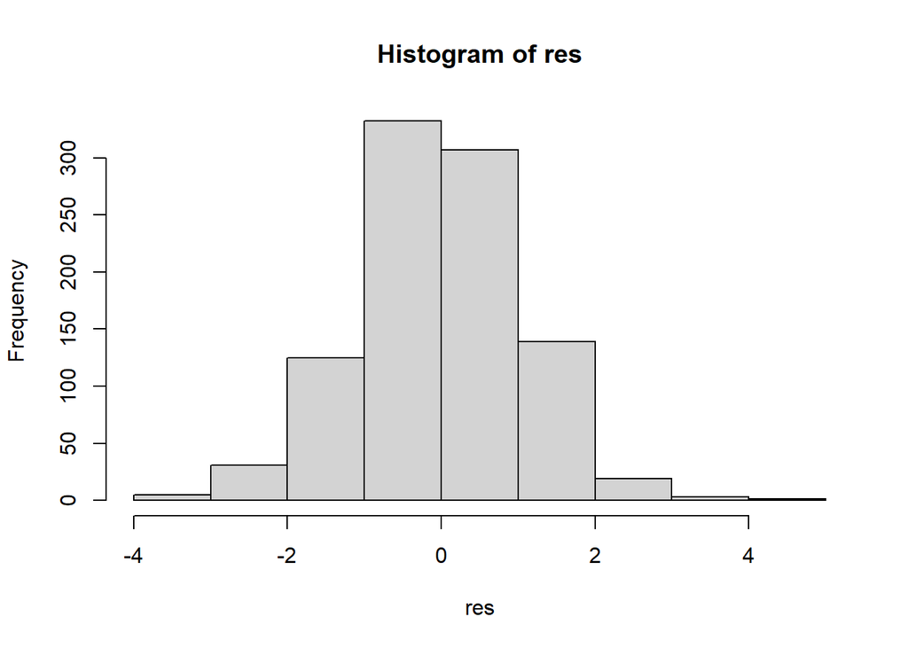

```r
res <- resid(fit2)
hist(res)
```

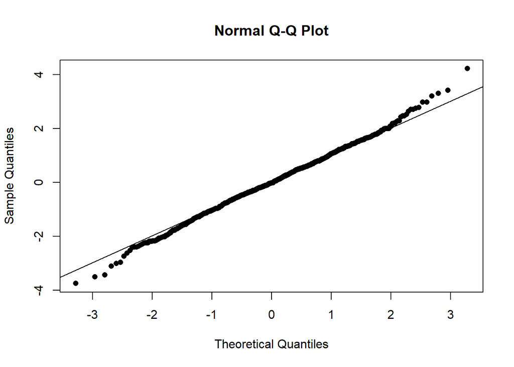

```r
qqnorm(res, pch=16)
qqline(res)
```

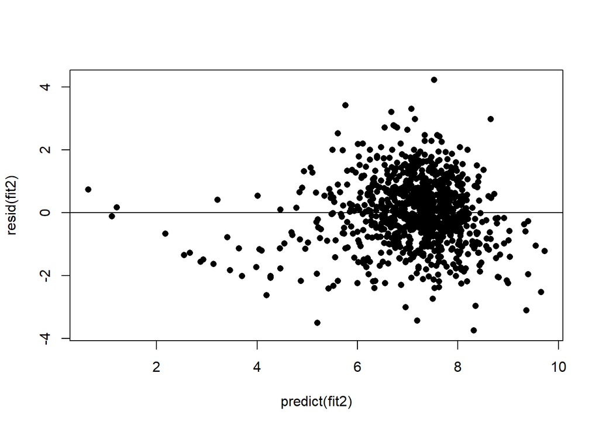

```r
plot(predict(fit2), resid(fit2), pch=16)
abline(h=0)
```

7. Provide a short interpretation of the partial slopes of your final model in the context of the problem.

**Resp:** For every one week increase in length of pregnancy, the expected increase in birth weight in pounds is 0.33.

The difference between mother’s marital status of “married” vs “not married” at the time of birth is expected to be 0.27 pounds in birth weight.

For every one pound increase in weight gained during pregnancy, the birth weight in pounds is expected to increase by 0.009.

The difference between gender of “male” vs “female” of the baby is expected to be 0.39 pounds in birth weight.

The difference between habit of “smoker” and “nonsmoker” for the mother is expected to be -0.38 pounds in birth weight.

The difference between the mother being classified as “white” or “not white” is expected to be 0.21 pounds in birth weight.